# Analiza trendów zakupowych

# 1 Wprowadzenie

Celem projektu jest analiza danych sprzedażowych, której zadaniem jest identyfikacja oraz zrozumienie wzorców zakupowych i preferencji klientów. Analiza ta ma na celu wyszczególnienie zależności występujących w danych, określenie charakterystyki zachowań konsumenckich oraz wskazanie czynników wpływających na decyzje zakupowe.

Wykorzystane zostały metody wstępnego przetwarzania danych, w szczególności techniki czyszczenia danych obejmujące identyfikację i eliminację braków danych. Zastosowane zostały narzędzia analizy danych, w tym techniki wizualizacji, umożliwiające przedstawienie rozkładów zmiennych, relacji pomiędzy nimi oraz identyfikację istotnych trendów.

Kluczowym elementem badania będzie również zastosowanie metod wnioskowania statystycznego, pozwalających na formułowanie i weryfikację hipotez badawczych oraz ocenę istotności zaobserwowanych zależności.

Przeprowadzona analiza ma na celu udzielenie odpowiedzi na sformułowane pytania badawcze, a także dostarczenie wniosków mogących stanowić podstawę do podejmowania decyzji biznesowych oraz dalszych badań analitycznych.

## 1.1 Opis danych

Analizowany zbiór danych zawiera **3900 obserwacji i 18 zmiennych.** W tabeli poniżej zostały przedstawione wszystkie zmienne wraz z informacjami na temat typu zmiennej, opisem i wartościami jakie przyjmuje.

Specyfikacja zmiennych w zbiorze danych

[output not shown]

# 2 Data Cleansing i Wrangling

## 2.1 Braki danych

Pierwszym etapem przeprowadzonej analizy danych było zweryfikowanie kompletności badanego zbioru danych, w szczególności identyfikacja występowania braków danych. W tym celu dokonano oceny liczby obserwacji niekompletnych oraz ich udziału procentowego w całym zbiorze.

W kolejnym kroku dokonano szczegółowej analizy braków danych wraz z badaniem struktury oraz wzorców występowania braków danych, w celu ustalenia, czy braki pojawiają się w sposób losowy, czy też wykazują określone zależności pomiędzy zmiennymi. Identyfikacja wzorców braków danych umożliwia podjęcie decyzji dotyczących dalszego postępowania z brakującymi obserwacjami.

### 2.1.1 Wzorzec braków danych

Pierwszym krokiem w analizie wzorców braków danych jest graficzne przedstawienie braków danych. Poniższy wykres wskazuje, że chociaż największa liczba obserwacji charakteryzuje się brakiem pojedynczej zmiennej, to występują również wyraźne przypadki jednoczesnych braków w więcej niż jednej zmiennej. Analiza mapy braków danych wskazuje na istnienie powtarzalnych wzorców współwystępowania braków w przypadku zmiennych: wiek (Age), wydatki (Amount) oraz sezon (Season), co sugeruje, że braki danych nie są całkowicie losowe.

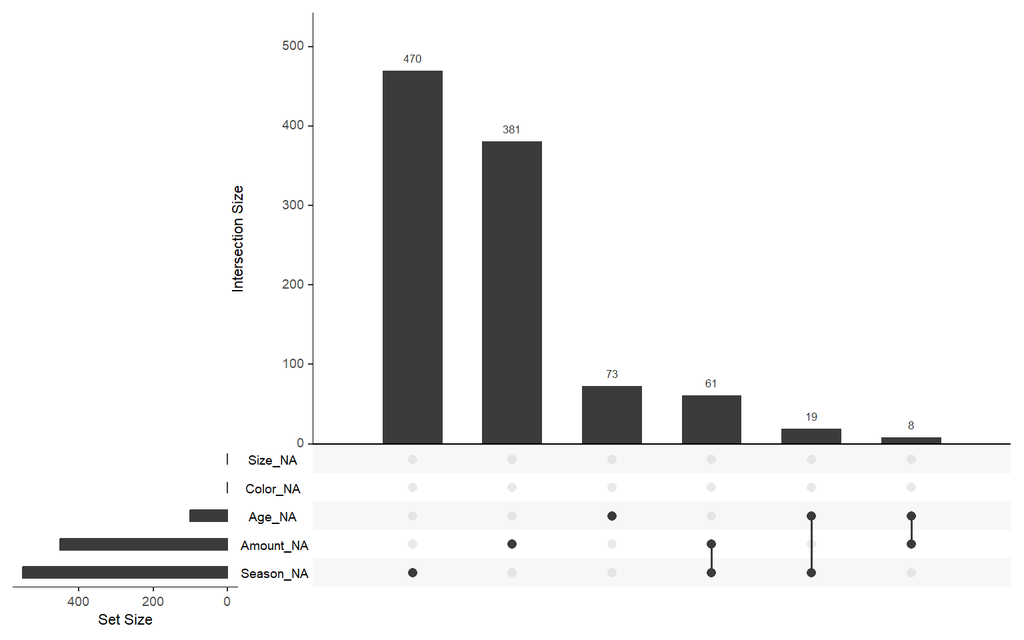

Z kolei analiza relacji pomiędzy samym wiekiem a wydaną kwotą pokazuje, że braki danych są rozproszone równomiernie, występują w całym zakresie kwot oraz u osób w każdym przedziale wiekowym. Oznacza to brak korelacji w występowaniu braków między tymi dwiema zmiennymi.

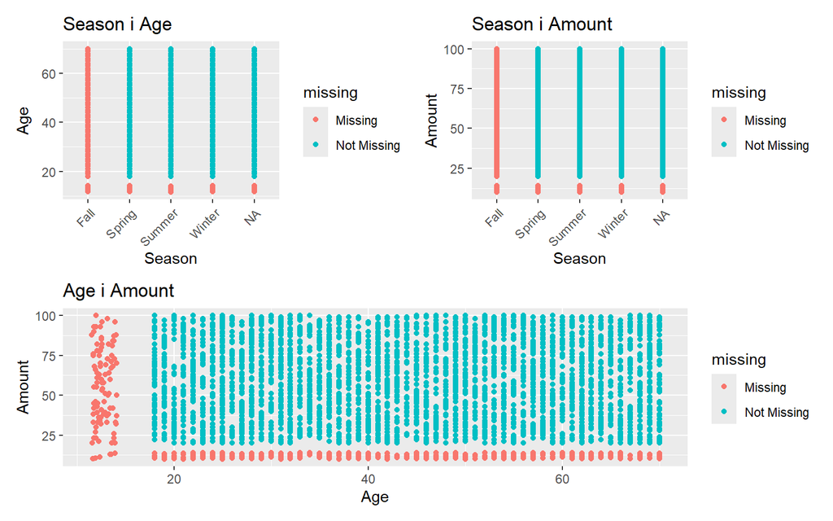

### 2.1.2 Imputacje metodą hotdeck

Imputacja metodą hotdeck polega na uzupełnianiu brakujących wartości poprzez przypisanie im rzeczywistych obserwacji pochodzących od statystycznie podobnych jednostek w tym samym zbiorze danych. Dobór tzw. dawcy odbywa się na podstawie zmiennych pomocniczych, które są kompletne i silnie powiązane z imputowaną cechą. W przeprowadzonej analizie wykorzystano imputację hotdeck w celu ograniczenia skali braków danych bez wprowadzania sztucznych wartości.

Po przeprowadzonej imputacji metodą hotdeck, zbiór danych został uzupełniony o brakujące wartości, co pozwoliło na uzyskanie kompletnego zestawu danych do dalszych analiz. Jak można zauważyć na poniższym wykresie, po zastosowaniu tej metody, zbiór danych nie zawiera już braków danych, co umożliwia przeprowadzenie dalszych analiz bez konieczności uwzględniania problemu niekompletności danych.

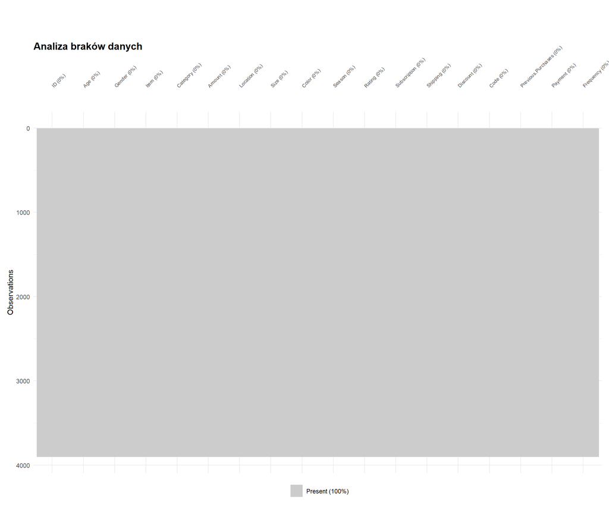

W celu sprawdzenie, czy zastosowana metoda imputacji hotdeck była skuteczna, przeprowadzono wizualną ocenę zgodności rozkładu zmiennych Age, Season i Amount przed i po imputacji. Poniższy wykres przedstawia porównanie rozkładów zmiennych w oryginalnym zbiorze danych z brakami oraz w zbiorze danych po imputacji. Analiza wizualna wskazuje, że rozkład zmiennych po imputacji jest zbliżony do rozkładu oryginalnego, co sugeruje, że metoda hotdeck skutecznie zachowała charakterystyki statystyczne tej zmiennej.

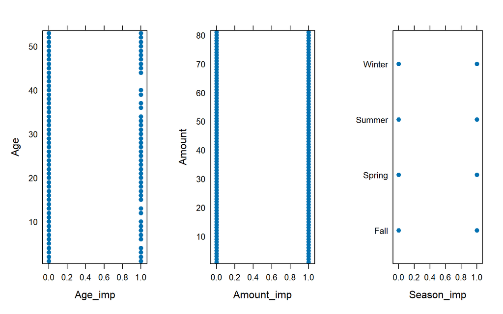

## 2.2 Walidacja danych

Przeprowadzona została walidacja danych, której celem jest zapewnienie poprawności, spójności oraz wiarygodności zbioru danych wykorzystywanego w dalszych analizach. Przeprowadzono weryfikację danych pod kątem zgodności wartości zmiennych z przyjętymi założeniami merytorycznymi oraz logicznymi ograniczeniami wynikającymi z charakteru analizowanego zjawiska. Sprawdzono m.in. poprawność zakresów zmiennych liczbowych, a także zgodność zmiennych jakościowych z dopuszczalnymi kategoriami. Przeprowadzone działania walidacyjne pozwoliły na przygotowanie spójnego i rzetelnego zbioru danych do dalszych etapów analizy.

**W ramach walidacji danych przyjęto następujące kryteria poprawności zmiennych:**

- Wiek (age) – wartości mieszczące się w przedziale od 0 do 120 lat.
- Płeć (gender) – zmienna jakościowa ograniczona do kategorii female oraz male.
- Kwota zakupu (purchase amount) – wartości dodatnie, większe od zera.
- Rozmiar (size) – dopuszczalne kategorie: XS, S, M, L, XL.
- Ocena opinii (review rating) – wartości z przedziału od 0 do 5.
- Liczba wcześniejszych zakupów (previous purchases) – wartości dodatnie, większe od zera.
- Zastosowanie rabatu (discount applied) – zmienna binarna: tak lub nie.
- Użycie kodu promocyjnego (promo code use) – zmienna binarna: tak lub nie.
- Subskrypcja (subscription) – zmienna binarna: tak lub nie.

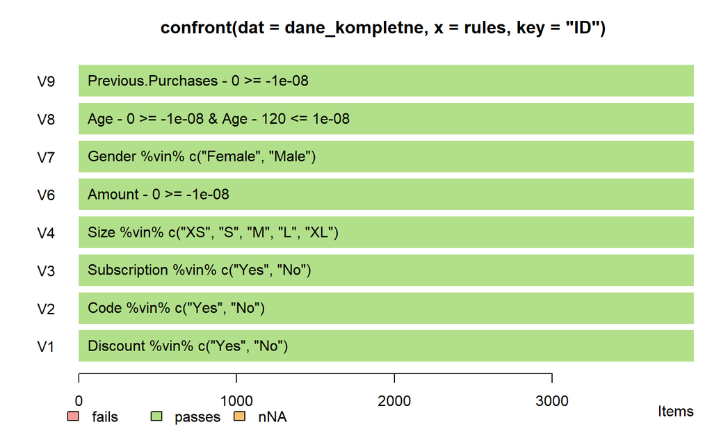

Przeprowadzona walidacja danych wskazała, że wszystkie obserwacje w zbiorze danych spełniają przyjęte kryteria poprawności dla poszczególnych zmiennych. Oznacza to, że dane są spójne i zgodne z założeniami merytorycznymi, co pozwala na ich dalsze wykorzystanie w analizie bez konieczności wprowadzania dodatkowych korekt czy eliminacji obserwacji.

# 3 Analiza opisowa

## 3.1 Statystyki opisowe zmiennych ilościowych

Kolejnym etapem badania jest szczegółowa analiza statystyczna zmiennej ilościowej Amount, która reprezentuje kwoty wydawane przez klientów podczas pojedynczej transakcji. Celem poniższego zestawienia jest nie tylko wyznaczenie przeciętnej wartości koszyka zakupowego, ale również zbadanie struktury tych wydatków – ich zróżnicowania, asymetrii oraz koncentracji wokół średniej. Z otrzymanych wyników można wywnioskować, że wydatki na różne kategorie produktów rozkładają się równomiernie, ponieważ mediana i średnia mają pododne wartości. Odchylenia standardowe w przypadku akcesorii (Accessories), ubrań (Clothing) i obuwia (Footwear) są bardzo zbliżone do siebie, co świadczy o tym, że klienci wydają podobne kwoty na te kategorie. Natomiast, widać trochę większe odchylenie w przypadku odzieży wierzchniej (Outerwear), co świadczy o tym, że w przypadku tej kategorii wydatki są bardziej zróżnicowane. Skośność bliska zeru wskazuje na symetryczny rozkład wydatków klientów. Sugeruje to, że struktura asortymentowa sklepu jest zbalansowana, a klienci równie chętnie wybierają produkty z dolnej, jak i górnej półki cenowej. Wyniki kurtozy oznaczają, że wydatki nie są mocno skoncentrowane wokół jednej kwoty, ale są dość równomiernie “rozsiane”.

Szczegółowa analiza statystyczna wydatków

| Category | Kategorie produktów Min | Kategorie produktów Max | Kategorie produktów Kwartyl dolny | Kategorie produktów Mediana | Kategorie produktów Kwartyl górny | Kategorie produktów Średnia | Kategorie produktów Odch. std. | Kategorie produktów IQR | Kategorie produktów Odchylenie ćwiartkowe | Kategorie produktów Odch. std. w % | Kategorie produktów Odch. ćwiartkowe w % | Kategorie produktów Skośność | Kategorie produktów Kurtoza |
| --- | --- | --- | --- | --- | --- | --- | --- | --- | --- | --- | --- | --- | --- |
| Accessories | 20 | 100 | 39 | 59 | 79 | 59.63 | 23.19 | 40 | 20.0 | 38.89 | 67.80 | 0.03 | -1.19 |
| Clothing | 20 | 100 | 39 | 60 | 81 | 60.13 | 23.64 | 42 | 21.0 | 39.31 | 70.00 | 0.00 | -1.24 |
| Footwear | 20 | 100 | 38 | 59 | 79 | 59.13 | 23.52 | 41 | 20.5 | 39.78 | 69.49 | 0.04 | -1.19 |
| Outerwear | 20 | 100 | 34 | 56 | 80 | 57.69 | 24.68 | 46 | 23.0 | 42.78 | 82.14 | 0.11 | -1.31 |

| Zmienna | Średnia (SD) |
| --- | --- |
| Wiek | 44 (15.22) |
| Kwota | 59.61 (23.57) |
| Ocena | 3.75 (0.72) |
| Kwota wydana na wcześniejszych zakupach | 25.35 (14.45) |

## 3.2 Korelacje zmiennych jakościowych

Dla badanego zbioru danych przeprowadzono analizę korelacji pomiędzy zmiennymi jakościowymi za pomocą współczynnika V-Craméra. Współczynnik ten mierzy siłę związku pomiędzy dwiema zmiennymi kategorycznymi, przyjmując wartości od 0 (brak związku) do 1 (pełna zależność).

[interactive chart not shown]

Analiza współzależności pomiędzy zmiennymi jakościowymi, wskazuje wyraźne skupiska silnych relacji w badanym zbiorze danych. Najbardziej widoczne jest powiązanie między zmiennymi Item i Category, co wskazuje, że typ produktu jest ściśle związany z jego klasyfikacją. Drugim istotnym skupiskiem zależności jest Code–Discount–Subscription, gdzie zarówno kod promocyjny, jak i rodzaj zastosowanej zniżki oraz status subskrypcji wykazują wzajemne, podwyższone powiązania. Sugeruje to, że określone kody i rabaty mogą być częściej kierowane do subskrybentów lub stosowane w ramach konkretnych strategii marketingowych.

## 3.3 Korelacja zmiennych ilościowych

Dla badanego zbioru danych przeprowadzono analizę korelacji pomiędzy zmiennymi ilościowymi z wykorzystaniem współczynnika korelacji Pearsona. Współczynnik ten mierzy siłę i kierunek liniowego związku pomiędzy dwiema zmiennymi liczbowymi, przyjmując wartości od -1 (silna korelacja ujemna) przez 0 (brak korelacji) do 1 (silna korelacja dodatnia). Wyniki zostały przedstawione na wykresie korelacji w formie macierzy kolorystycznej, gdzie intensywność barw odzwierciedla siłę zależności pomiędzy zmiennymi: wiekiem, kwotą zakupu, oceną oraz liczbą wcześniejszych zakupów.

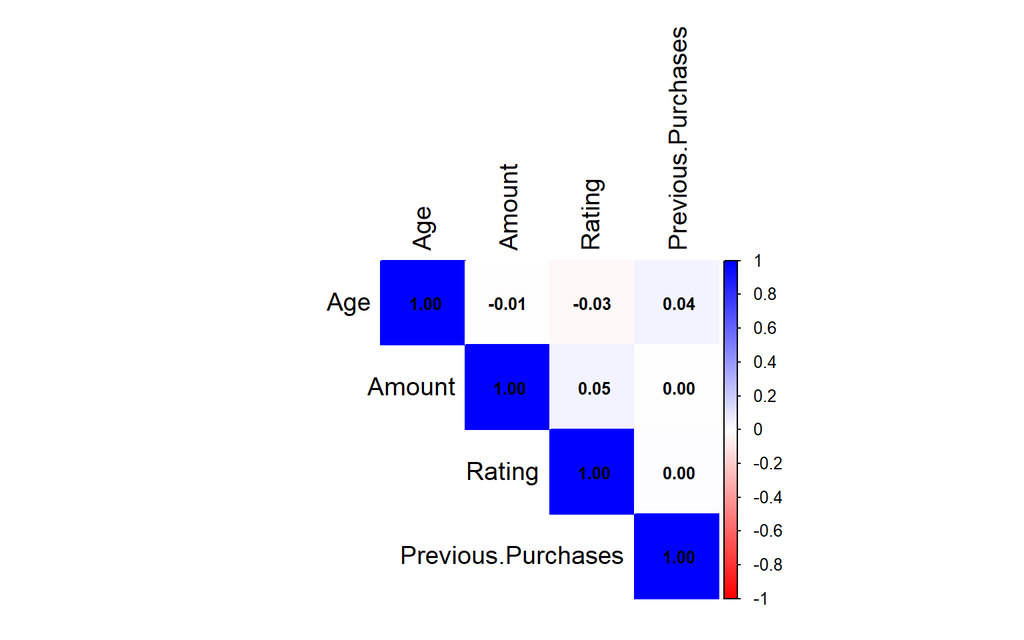

# 4 Wizualizacja danych

Wizualizacja danych stanowi istotny element procesu analizy danych, umożliwiający przejrzyste i intuicyjne przedstawienie informacji zawartych w zbiorze danych.

W niniejszym rozdziale zaprezentowano wybrane metody wizualizacji danych wykorzystane w celu lepszego zrozumienia analizowanych zjawisk.

*W ramach przeprowadzonej analizy sformułowano następujące pytania badawcze:*

1. Czy wiek konsumentów wpływa na wybór kategorii zakupionych przedmiotów?
2. Czy wiek konsumentów wpływa na wysokość kwoty zakupu?
3. Jakie są najpopularniejsze kombinacje rozmiarów i kolorów w poszczególnych kategoriach?
4. Jakie są preferencje klientów dotyczące metod płatności w zależności od grupy wiekowej?
5. Czy klienci wydający więcej wybierają szybsze opcje wysyłki?
6. Czy większa liczba klientów wpływa na wyższą sprzedaż w poszczególnych lokalizacjach?
7. Czy klienci którzy wystawiają lepszą ocenę częściej kupują?
8. Czy istnieją znaczące różnice w kategoriach i kwotach zakupów w zależności od lokalizacji i sezonu?
9. Czy sezon wpływa na wartość zakupów w poszczególnych kategoriach?
10. Czy płeć wpływa na zakup produktów z poszczególnych kategorii?
11. Czy posiadanie subskrypcji wpływa na częstotliwość zakupów?
12. Jaka jest średnia ocen zakupów dla poszczególnych stanów?

## 4.1 Czy wiek konsumentów wpływa na wybór kategorii zakupionych przedmiotów?

Aby odpowiedzieć na to pytanie badawcze przedstawiono skumulowany wykres słupkowy ilustrujący rozkład kategorii zakupionych produktów w podziale na grupy wiekowe. Grupy wiekowe zostały zdefiniowane jako: 18-29, 30-44, 45-59 oraz 60+. Wykres ten pozwala na wizualne porównanie udziału procentowego poszczególnych kategorii w różnych grupach wiekowych, co umożliwia ocenę wpływu wieku na wybór kategorii zakupionych przedmiotów.

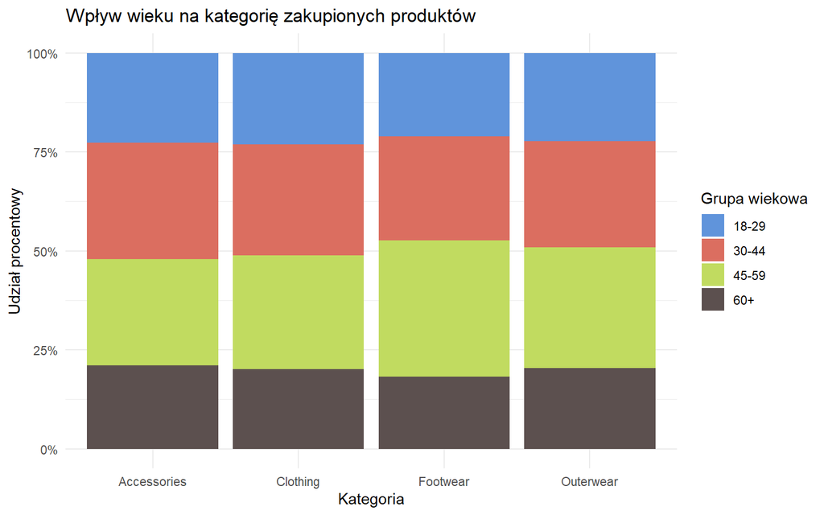

## 4.2 Czy wiek konsumentów wpływa na wysokość kwoty zakupu?

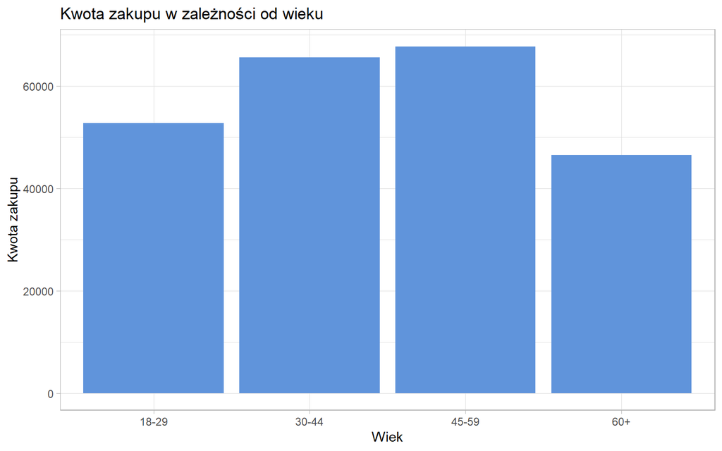

## 4.3 Jakie są najpopularniejsze kombinacje rozmiarów i kolorów w poszczególnych kategoriach?

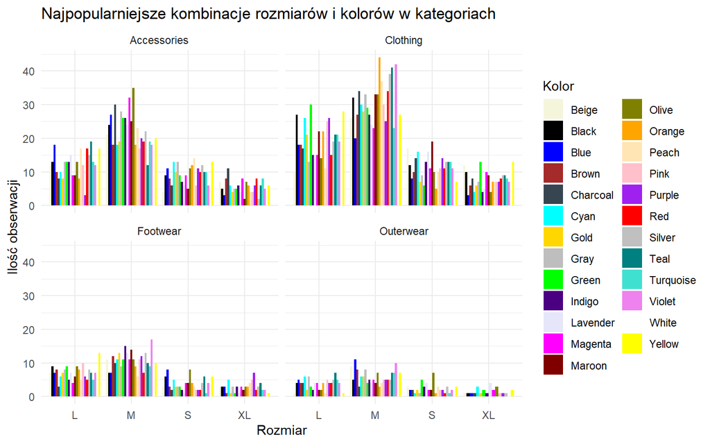

## 4.4 Jakie są preferencje klientów dotyczące metod płatności w zależności od grupy wiekowej?

[figure not shown]

## 4.5 Czy klienci wydający więcej wybierają szybsze opcje wysyłki?

Preferencje klientów dotyczące wyboru rodzaju wysyłki zostały przedstawione na wykresie pudełkowym, gdzie każda kategoria wysyłki (Store Pickup, Standard, Next Day Air, Free Shipping, Express, 2-Day Shipping) została zilustrowana osobnym boxplotem obrazującym rozkład wydatków. Na osi Y znajdują się typy wysyłki, natomiast oś X przedstawia wartość zakupów. Wykres pozwala porównać medianę, rozrzut oraz obecność wartości odstających w każdej grupie.

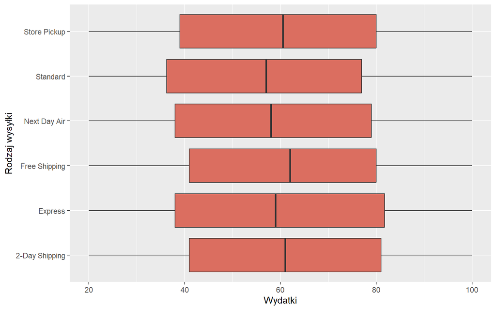

## 4.6 Czy większa liczba klientów wpływa na wyższą sprzedaż w poszczególnych lokalizacjach?

Korelacja między całkowitą sprzedarzą a liczbą klientów w poszczególnych lokalizacjach została przedstawiona na wykresie punktowym. Na osi X znajduje się całkowita sprzedaż w danej lokalizacji, natomiast na osi Y liczba klientów, natomiast każdy punk odpowiada za jedną lokalizację. Na wykresie widoczny jest trend wzrostowy. Wraz ze wzrostem liczby klientów w danej lokalizacji, proporcjonalnie rośnie całkowita sprzedaż.Punkty układają się wzdłuż linii diagonalnej, co sugeruje silną, liniową zależność między tymi zmiennymi. Potwierdza to wysoki wynik współczynnika korelacji Pearsona, który wynosi 0,88**.** Największe skupisko obserwacji znajduje się w środkowej części wykresu. Oznacza to, że większość lokalizacji osiąga zbliżone, średnie wyniki operacyjne. W prawym górnym rogu wykresu widoczne są punkty reprezentujące najbardziej dochodowe lokalizacje.

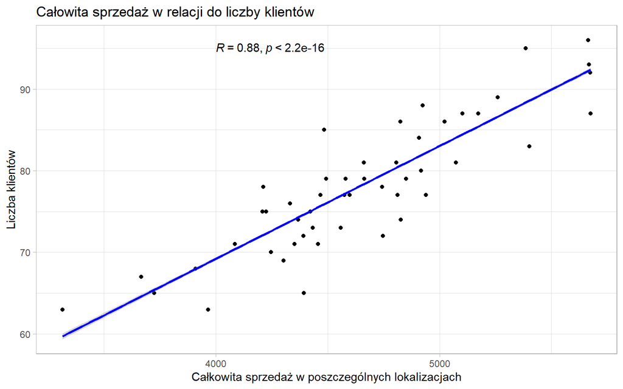

## 4.7 Czy klienci którzy wystawiają lepszą ocenę częściej kupują?

Preferencje klientów w zakresie liczby wcześniejszych zakupów w zależności od wystawionej oceny zostały przedstawione na wykresie pudełkowym, gdzie na osi X znajdują się trzy poziomy ocen: średnia (Medium), wysoka (High) oraz bardzo wysoka (Very High). Oś Y obrazuje liczbę poprzednich zakupów, a każdy poziom oceny został oznaczony innym kolorem, co ułatwia porównanie rozkładów.

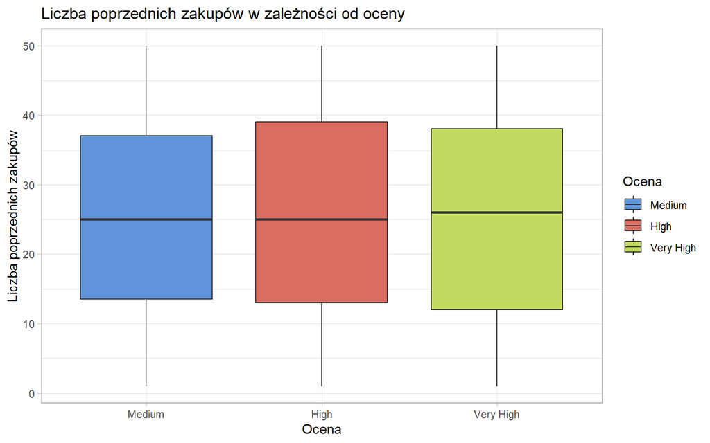

## 4.8 Czy istnieją znaczące różnice w kategoriach i kwotach zakupów w zależności od lokalizacji i sezonu?

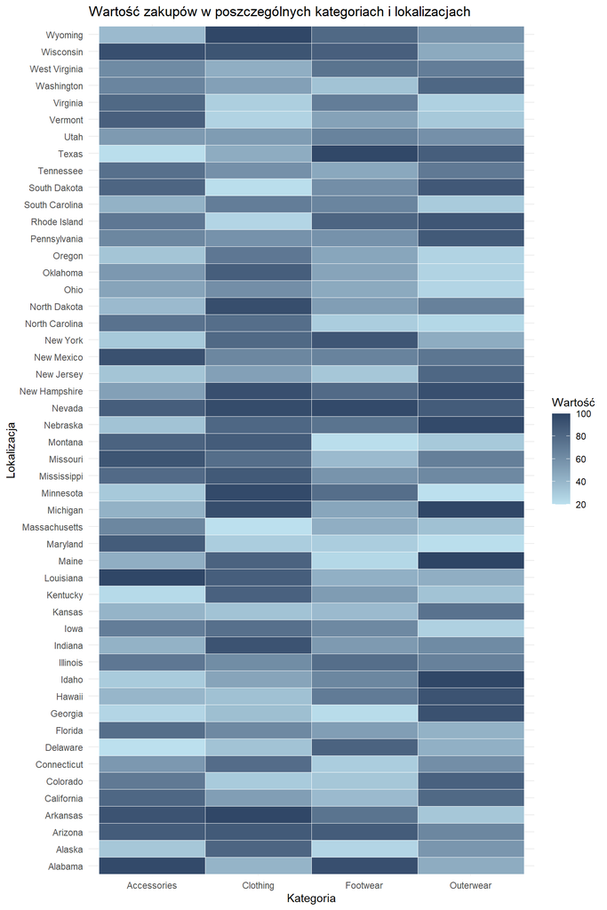

## 4.9 Czy sezon wpływa na wartość zakupów w poszczególnych kategoriach?

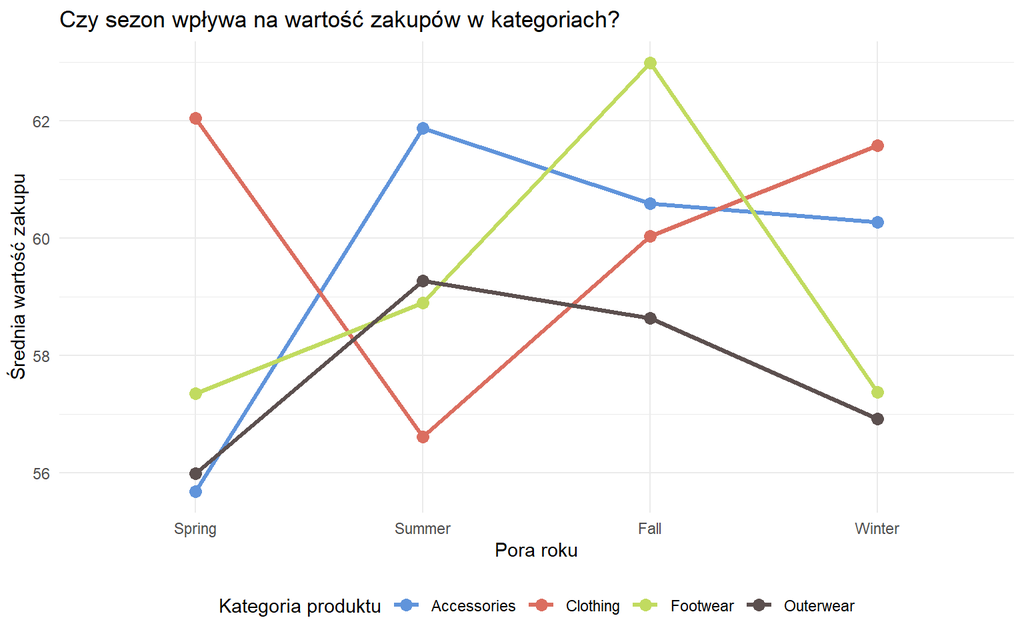

## 4.10 Czy płeć wpływa na zakup produktów z poszczególnych kategorii?

Preferencje zakupowe klientów w poszczególnych kategoriach produktów z podziałem na płeć zostały przedstawione na mapie cieplnej, gdzie intensywność koloru odzwierciedla liczbę dokonanych zakupów. Na osi X znajduje się płeć, a na osi Y cztery kategorie produktów: Outerwear, Footwear, Clothing oraz Accessories. Im ciemniejszy odcień niebieskiego, tym większa liczba zakupów w danej grupie.

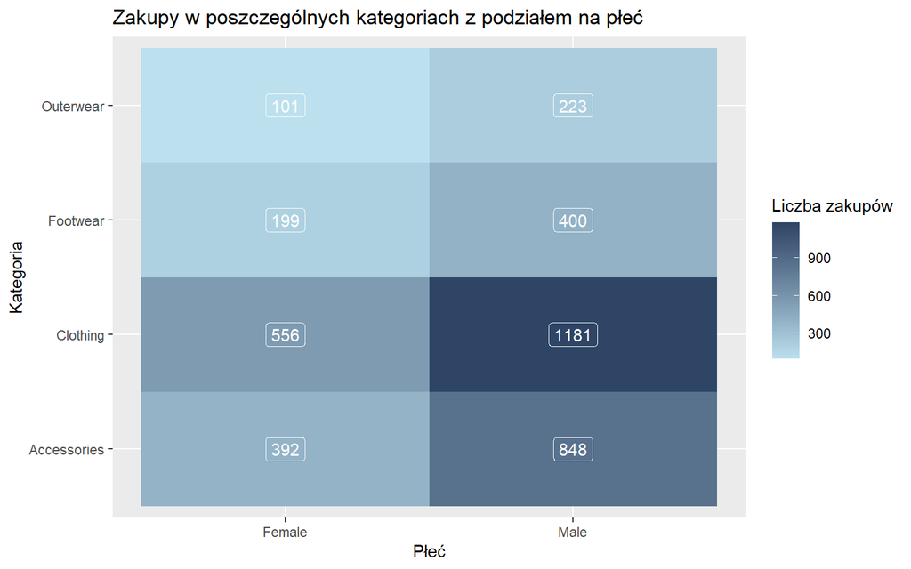

Analiza wykresu pokazuje, że mężczyźni dokonują więcej zakupów niż kobiety we wszystkich kategoriach. Największe różnice widoczne są w kategorii odzieży, gdzie mężczyźni dokonali ponad dwukrotnie więcej transakcji niż kobiety (1181 vs 556). Podobna tendencja występuje w przypadku akcesoriów i obuwia. Najmniejsza różnica występuje w kategorii odzieży wierzchniej, choć i tu mężczyźni przeważają. Dane mogą sugerować większą aktywność zakupową mężczyzn w analizowanym okresie lub ich większe zainteresowanie konkretnymi kategoriami produktów.

## 4.11 Czy posiadanie subskrypcji wpływa na częstotliowść zakupów?

Zależność między posiadaniem subskrypcji a częstotliwością dokonywania zakupów została również przedstawiona na mapie cieplnej, gdzie intensywność koloru odzwierciedla liczbę transakcji w różnych przedziałach czasowych. Na osi X znajduje się informacja o posiadaniu subskrypcji, natomiast oś Y przedstawia częstotliwość zakupów: tygodniową, dwutygodniową, miesięczną, kwartalną, coroczną oraz inne warianty. Każda komórka zawiera konkretną liczbę zakupów, co pozwala na bezpośrednie porównanie aktywności zakupowej użytkowników z subskrypcją i bez niej.

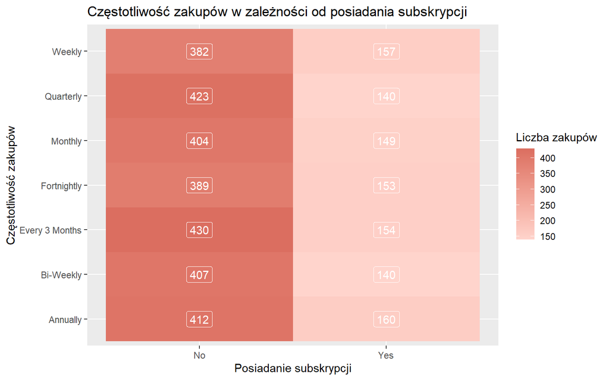

Analiza wykresu wskazuje, że użytkownicy bez subskrypcji dokonują więcej zakupów we wszystkich kategoriach częstotliwości niż osoby posiadające subskrypcję. Może to sugerować, że subskrypcja niekoniecznie zwiększa częstotliwość zakupów, a wręcz przeciwnie — osoby bez niej wykazują większą aktywność zakupową.

## 4.12 Średnia ocen zakupów w poszczególnych stanach

Średnia ocen zakupów w poszczególnych stanach została przedstawiona na mapie Stanów Zjednoczonych. Kolory na mapie reprezentują średnią ocenę zakupów w danym stanie, gdzie odcienie czerwieni wskazują niższe średnie oceny, a odcienie zieleni wyższe. Regionami o najwyższej satysfakcji z zakupów to takie stany jak Teksas (TX), Wisconsin (WI) oraz Waszyngton (WA). Wyraźnie niższe oceny widoczne są w stanach Oklahoma (OK), Georgia (GA) oraz Wirginia Zachodnia (WV). Średnia w tych lokalizacjach zbliża się do dolnej granicy skali (3.6). Stany w centralnej części USA (np. Nebraska, Kansas) oraz na północnym wschodzie (np. Maine, Vermont) prezentują umiarkowany, stabilny poziom satysfakcji (kolory żółte i jasnozielone).

[interactive chart not shown]

# 5 Wnioskowanie statystyczne

## 5.1 Analiza wpływu wieku konsumentów na wybór kategorii zakupionych przedmiotów

Celem analizy jest zbadanie, czy wiek konsumentów wpływa na wybór kategorii zakupionych produktów. Wykorzystano wykres słupkowy z podziałem procentowym oraz test chi-kwadrat Pearsona, aby ocenić, czy rozkład wyborów produktowych różni się istotnie pomiędzy grupami wiekowymi. Dodatkowo obliczono wartość V Cramera jako miarę siły zależności oraz p‑value dla każdej kategorii osobno.

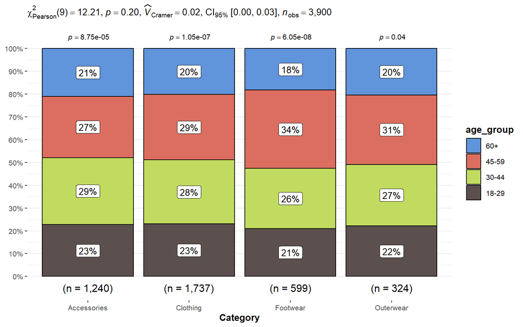

## 5.2 Analiza porównawcza kwot wydatków w podziale na kategorie

Celem poniższej analizy jest porównanie rozkładu wydatków klientów w zależności od kategorii zakupionych produktów. Zmienna Amount reprezentuje kwotę pojedynczej transakcji, natomiast zmienna Category dzieli zakupy na cztery grupy: Accessories, Clothing, Footwear oraz Outerwear. Analiza ma na celu ocenę, czy kategorie różnią się istotnie pod względem wysokości wydatków, oraz czy struktura tych wydatków wskazuje na zróżnicowane preferencje konsumenckie. Wykorzystano zarówno klasyczne testy statystyczne (Welch’s ANOVA), jak i podejście bayesowskie, aby uzyskać pełniejszy obraz zależności.

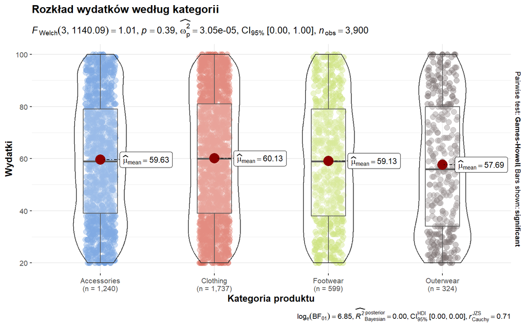

Statystycznie, test Welch’a ANOVA wykazał brak istotnych różnic między grupami. Wartość standaryzowanej miary efektu wskazuje, że kategoria produktu nie wyjaśnia żadnej części wariancji wydatków. Przedział ufności dla siły efektu jest bardzo szeroki, co dodatkowo podkreśla niepewność wyniku. Analiza bayesowska potwierdza ten wniosek.

Podsumowując, zarówno wizualizacja, jak i testy statystyczne jednoznacznie wskazują, że wydatki klientów nie różnią się istotnie w zależności od kategorii produktu. Średnie wartości są niemal identyczne, a brak efektu potwierdzają zarówno podejścia klasyczne, jak i bayesowskie.

## 5.3 Analiza wpływu grupy wiekowej na preferencje dotyczące wyboru metod płatności

Celem niniejszej analizy jest zbadanie, czy wiek konsumentów wpływa na preferencje dotyczące wyboru metod płatności. Analiza ma charakter eksploracyjny i została przeprowadzona przy użyciu wykresu słupkowego z podziałem procentowym, który pozwala ocenić, jak rozkładają się wybory płatnicze w poszczególnych grupach wiekowych. Dodatkowo zastosowano test chi-kwadrat Pearsona oraz współczynnik V Cramera, aby określić, czy obserwowane różnice mają charakter statystycznie istotny i jak silna jest zależność między wiekiem a preferencją płatniczą.

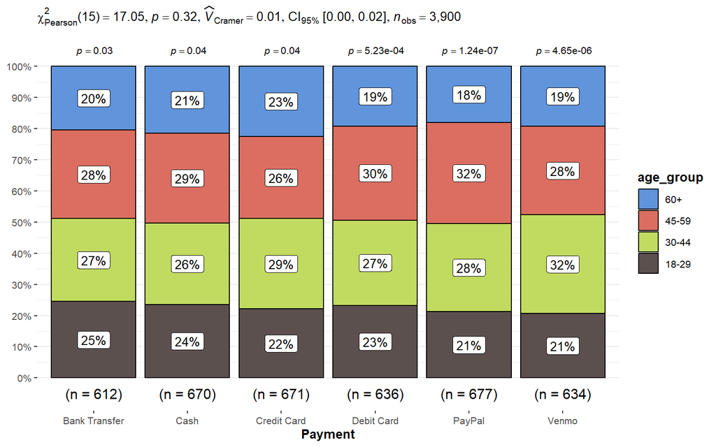

## 5.4 Analiza wpływu sezonu na wartość zakupów w poszczególnych kategoriach

W kontekście badania zachowań konsumenckich warto przyjrzeć się, czy sezon zakupowy oraz typ produktu wpływają na wysokość wydatków. Analiza wariancji (ANOVA) z uwzględnieniem interakcji między tymi zmiennymi pozwala ocenić, czy wydatki różnią się istotnie w zależności od sezonu, kategorii produktu, oraz czy efekt sezonu zależy od rodzaju kupowanego towaru.

Wyniki analizy wariancji dla zmiennej Amount

| Efekt | Df | Suma kwadratów | Średni kwadrat | Statystyka F | p-value |
| --- | --- | --- | --- | --- | --- |
| Season | 3 | 2227.343 | 742.448 | 1.344 | 0.258 |
| Category | 3 | 1808.429 | 602.810 | 1.091 | 0.352 |
| Season:Category | 9 | 15809.266 | 1756.585 | 3.179 | 0.001 |
| Residuals | 3884 | 2145922.958 | 552.503 | NA | NA |

## 5.5 Analiza wpływu oceny produktu i płci na wysokość wydatków - dwuskładnikowa analiza ANOVA

Celem analizy jest ocena wpływu dwóch zmiennych: Rating (ocena produktu) oraz Gender (płeć klienta) na wysokość wydatków (Amount). W tym celu zastosowano analizę wariancji ANOVA z uwzględnieniem interakcji między zmiennymi, co pozwala nie tylko ocenić ich indywidualny wpływ, ale również sprawdzić, czy efekt jednej zmiennej zależy od poziomu drugiej.

Wyniki analizy wariancji dla zmiennej Amount

| Efekt | Df | Suma kwadratów | Średni kwadrat | Statystyka F | p-value |
| --- | --- | --- | --- | --- | --- |
| Rating | 1 | 4611.546 | 4611.546 | 8.323 | 0.004 |
| Gender | 1 | 1884.062 | 1884.062 | 3.400 | 0.065 |
| Rating:Gender | 1 | 564.316 | 564.316 | 1.018 | 0.313 |
| Residuals | 3896 | 2158708.072 | 554.083 | NA | NA |

Wyniki analizy wariancji wskazują, że zmienna Rating ma istotny wpływ na wysokość wydatków. Oznacza to, że ocena produktu wiąże się ze statystycznie istotnymi różnicami w kwocie wydatków, czyli klienci mogą wydawać więcej na produkty, które oceniają wyżej, lub odwrotnie, wyższe wydatki mogą być związane z wyższymi oczekiwaniami i ocenami.

Zmienna Gender nie wykazuje istotnego wpływu na wydatki. Oznacza to, że średnie wydatki nie różnią się istotnie pomiędzy kobietami a mężczyznami w badanej próbie.

Interakcja Rating × Gender również nie jest istotna statystycznie. Wskazuje to, że wpływ oceny produktu na wydatki nie zależy od płci klienta.

## 5.6 Analiza zależność między płcią a kategorią zakupionych przedmiotów?

W tej części analizy sprawdzono, czy istnieje zależność między zmienną Gender (płeć) a wyborem kategorii zakupionych produktów (Category). Wykorzystano wykres słupkowy z podziałem procentowym oraz test chi-kwadrat Pearsona, aby ocenić, czy rozkład wyborów produktowych różni się istotnie pomiędzy kobietami a mężczyznami. Dodatkowo obliczono wartość V Cramera jako miarę siły zależności oraz p‑value dla każdej kategorii osobno.

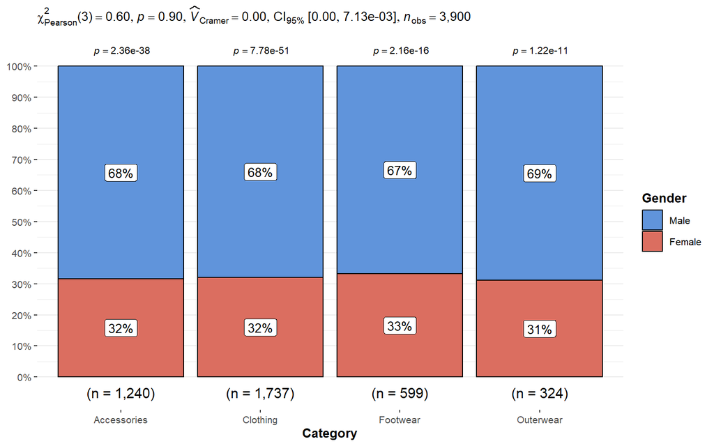

W każdej z czterech kategorii dominują mężczyźni, stanowiąc około 67–69% kupujących, podczas gdy kobiety odpowiadają za 31–33% transakcji. Rozkład ten jest bardzo podobny we wszystkich kategoriach, co sugeruje brak wyraźnych różnic w preferencjach produktowych między płciami.

Wartość testu chi-kwadrat Pearsona oznacza to, że nie ma statystycznie istotnej zależności między płcią a wyborem kategorii produktu. Wartość współczynnika Cramera oraz przedział ufności wskazują na całkowity brak efektu.

## 5.7 Analiza wpływu oceny produktu, płci i wieku na kwotę zakupu z wykorzystaniem ANCOVA

Analiza kowariancji ANCOVA została przeprowadzona w celu zbadania wpływu zmiennej Rating (oceny produktu) na zmienną zależną Amount (wartości zakupu), przy jednoczesnym kontrolowaniu potencjalnego wpływu zmiennych Gender (płeć) oraz Age (wiek). Dodatkowo uwzględniono interakcję między zmiennymi Rating i Gender, aby sprawdzić, czy wpływ oceny produktu na wartość zakupu różni się w zależności od płci.

Wyniki analizy ANCOVA

| Efekt | Df | Suma kwadratów | Średni kwadrat | Statystyka F | p-value |
| --- | --- | --- | --- | --- | --- |
| Rating | 1 | 4611.546 | 4611.546 | 8.321 | 0.004 |
| Gender | 1 | 1884.062 | 1884.062 | 3.400 | 0.065 |
| Age | 1 | 160.942 | 160.942 | 0.290 | 0.590 |
| Rating:Gender | 1 | 561.772 | 561.772 | 1.014 | 0.314 |
| Residuals | 3895 | 2158549.674 | 554.185 | NA | NA |

Podsumowując, w analizowanym modelu kwota zakupu jest istotnie związana wyłącznie z poziomem oceny produktu, natomiast płeć, wiek oraz interakcja oceny produktu z płcią nie mają istotnego znaczenia statystycznego.

# 6 Podsumowanie i wnioski końcowe

Projekt analityczny przeprowadzony na zbiorze danych konsumenckich dostarczył kompleksowego wglądu w zachowania zakupowe klientów w zależności od takich zmiennych jak wiek, płeć, ocena produktu, sezon zakupowy oraz preferencje płatnicze. Wykorzystano szereg metod statystycznych — od testów korelacji, przez analizę wariancji ANOVA, po testy chi-kwadrat i miary siły efektu, co pozwoliło na wielowymiarową ocenę zależności między zmiennymi.

*Najważniejsze obserwacje:*